# Modeling & Forecasting Atmospheric Carbon Concetration

## Validating the Model

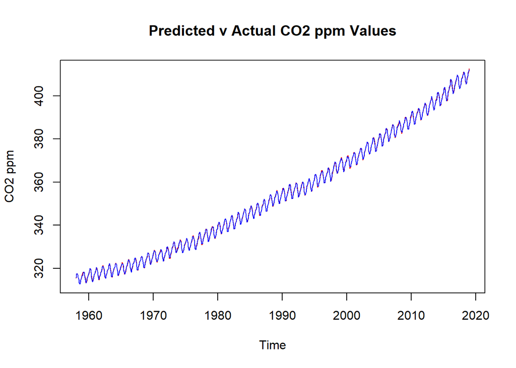

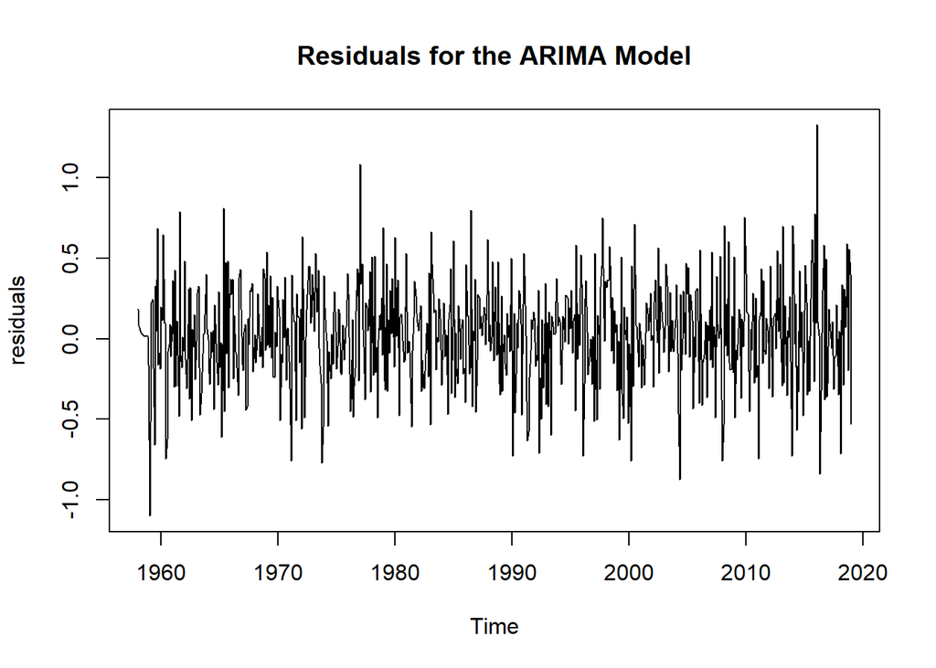

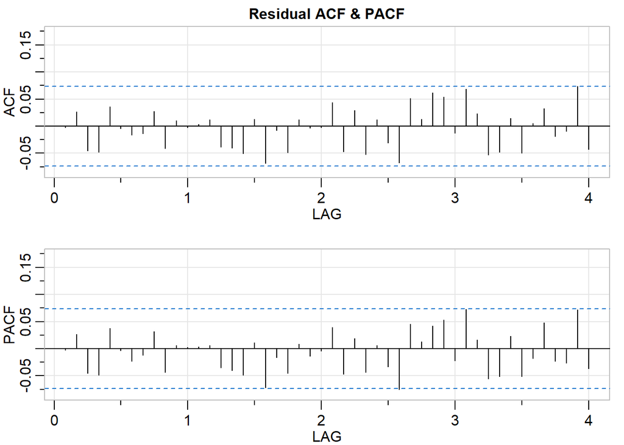

- When we plot the predicted values against the actual data, the two are virtually indistinguishable which means that our model is a good fit for our data.
- The residuals are centered around zero and have a constant variance so it seems like nothing other than white noise is left unaccounted for.
- The ACF & PACF both fall within the significance limits!

#### Ljung-Box test

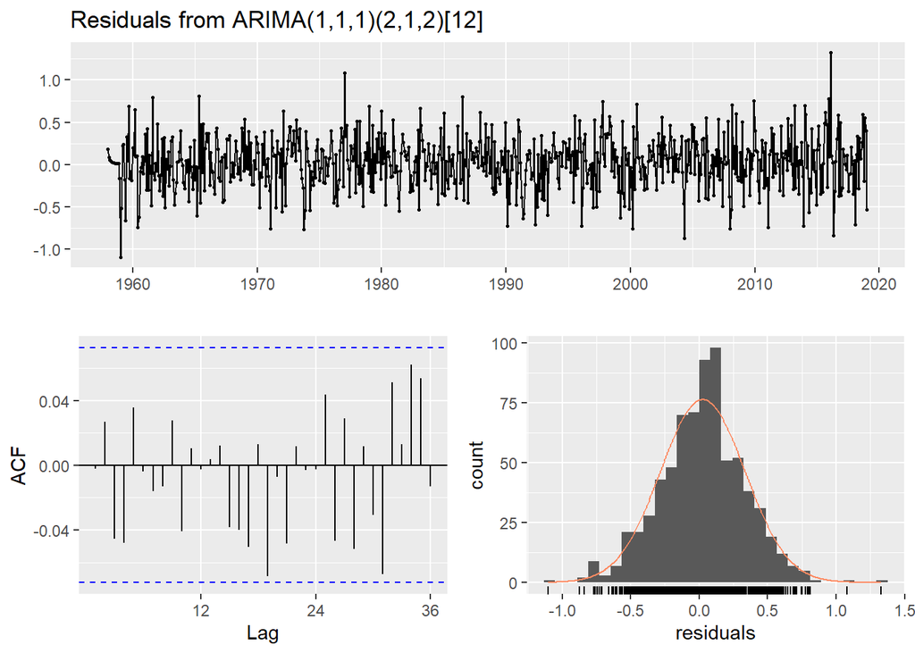

```
##
##  Ljung-Box test
##
## data:  Residuals from ARIMA(1,1,1)(2,1,2)[12]
## Q* = 6.9202, df = 6, p-value = 0.3283
##
## Model df: 6.   Total lags used: 12
```

## Forecasting using Cross Validation

#### Creating Training and Testing Data set:

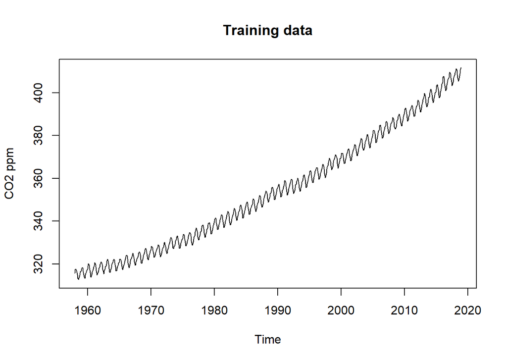

#### Creating the SARIMA Model

```
##
##  Fitting models using approximations to speed things up...
##
##  ARIMA(2,1,2)(1,1,1)[12]                    : 417.3212
##  ARIMA(0,1,0)(0,1,0)[12]                    : 874.2091
##  ARIMA(1,1,0)(1,1,0)[12]                    : 606.937
##  ARIMA(0,1,1)(0,1,1)[12]                    : 437.5698
##  ARIMA(2,1,2)(0,1,1)[12]                    : 428.1664
##  ARIMA(2,1,2)(1,1,0)[12]                    : 591.773
##  ARIMA(2,1,2)(2,1,1)[12]                    : 398.8025
##  ARIMA(2,1,2)(2,1,0)[12]                    : 497.5467
##  ARIMA(2,1,2)(2,1,2)[12]                    : 396.9926
##  ARIMA(2,1,2)(1,1,2)[12]                    : 408.9982
##  ARIMA(1,1,2)(2,1,2)[12]                    : 388.5148
##  ARIMA(1,1,2)(1,1,2)[12]                    : 405.4638
##  ARIMA(1,1,2)(2,1,1)[12]                    : 390.8945
##  ARIMA(1,1,2)(1,1,1)[12]                    : 410.6434
##  ARIMA(0,1,2)(2,1,2)[12]                    : 391.3334
##  ARIMA(1,1,1)(2,1,2)[12]                    : 387.5738
##  ARIMA(1,1,1)(1,1,2)[12]                    : 403.8803
##  ARIMA(1,1,1)(2,1,1)[12]                    : 389.8328
##  ARIMA(1,1,1)(1,1,1)[12]                    : 408.6687
##  ARIMA(0,1,1)(2,1,2)[12]                    : 390.9683
##  ARIMA(1,1,0)(2,1,2)[12]                    : 407.071
##  ARIMA(2,1,1)(2,1,2)[12]                    : 396.3372
##  ARIMA(0,1,0)(2,1,2)[12]                    : Inf
##  ARIMA(2,1,0)(2,1,2)[12]                    : 403.1876
##
##  Now re-fitting the best model(s) without approximations...
##
##  ARIMA(1,1,1)(2,1,2)[12]                    : 386.7956
##
##  Best model: ARIMA(1,1,1)(2,1,2)[12]
```

```
## Series: co2_training
## ARIMA(1,1,1)(2,1,2)[12]
##
## Coefficients:
##          ar1      ma1     sar1     sar2     sma1     sma2
##       0.1806  -0.5469  -0.4106  -0.0357  -0.4571  -0.3439
## s.e.  0.0961   0.0827   0.6973   0.0438   0.6968   0.6037
##
## sigma^2 estimated as 0.09865:  log likelihood=-186.32
## AIC=386.64   AICc=386.8   BIC=418.68
##
## Training set error measures:
##                      ME      RMSE       MAE         MPE      MAPE      MASE
## Training set 0.02554781 0.3099845 0.2399844 0.006916028 0.0679221 0.1533923
##                      ACF1
## Training set -0.002077693
```

#### Validating the Forecasting Model

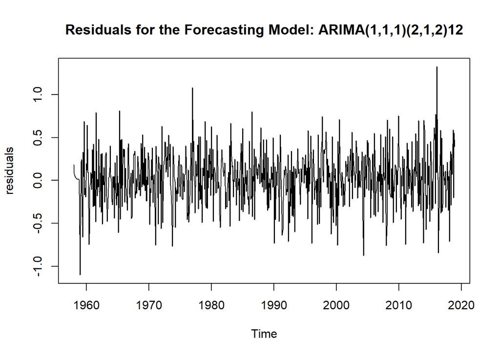

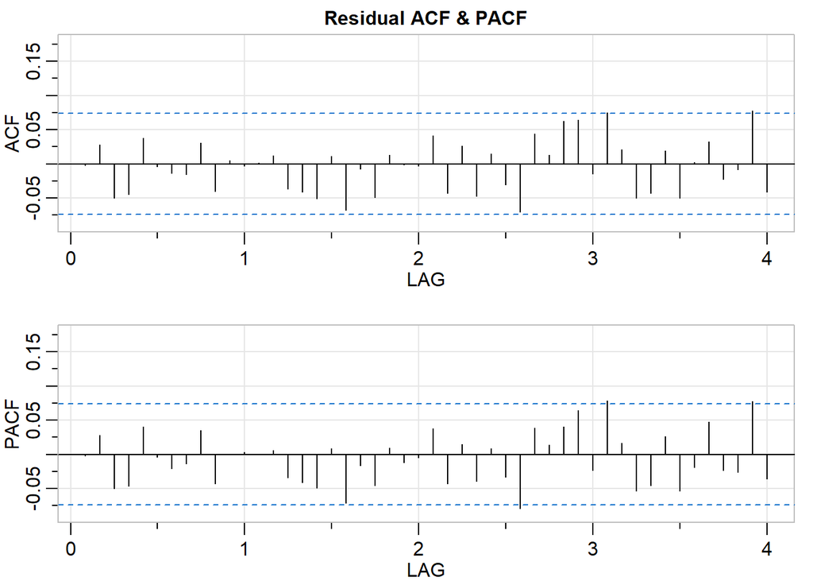

- Just by looking at the remaining residuals from our forecasting model, we can see that the errors are white noise. The ACF and PACF fall within the significance limits; these two plots are strong indicators that the model will pass the Ljung-Box test.

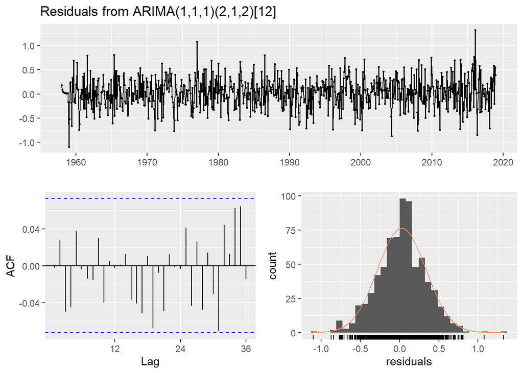

```
##
##  Ljung-Box test
##
## data:  Residuals from ARIMA(1,1,1)(2,1,2)[12]
## Q* = 16.971, df = 18, p-value = 0.5251
##
## Model df: 6.   Total lags used: 24
```

## Forecasts

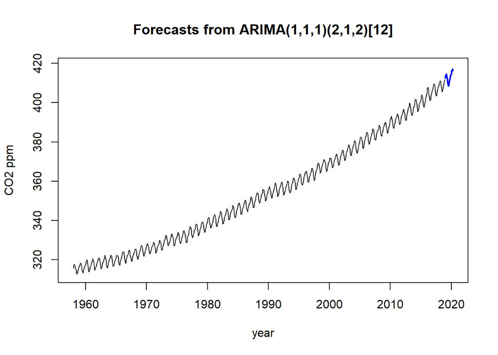

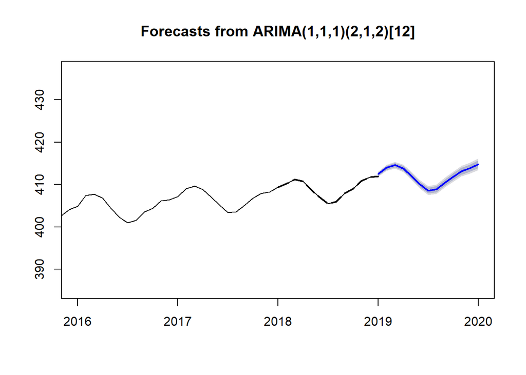

```
##                       ME      RMSE       MAE          MPE      MAPE      MASE
## Training set  0.02554781 0.3099845 0.2399844  0.006916028 0.0679221 0.1533923
## Test set     -0.53558910 0.5355891 0.5355891 -0.130006820 0.1300068 0.3423358
##                      ACF1
## Training set -0.002077693
## Test set               NA
```

## Results and Insights

The model used to forecast carbon dioxide concentration in the atmosphere was a Seasonal ARIMA(1,1,1)(2,1,2)12

**Forecast errors for the SARIMA model**

```
##                       ME      RMSE       MAE          MPE      MAPE      MASE
## Training set  0.02554781 0.3099845 0.2399844  0.006916028 0.0679221 0.1533923
## Test set     -0.53558910 0.5355891 0.5355891 -0.130006820 0.1300068 0.3423358
##                      ACF1
## Training set -0.002077693
## Test set               NA
```